# Bataan Free-Port Zone (Class Trip)

Arlegui, Sofia & Rosacay,Craig

29 November 2017

# **GuangQiang Manufacturing Corporation**

Introduction

GuangQuiang Manufacturing Corporation is a Chinese corporation located, in Freeport Area of Bataan, Mariveles. The corporation purely focuses on the manufacturing and producing mold and fitted materials for Handbag factories and Shoe Factory. They are also flexible in supplying of materials like bontex (fabric stiffener), fabric paper, bonded leather and lining fabric etc. They are the one who also supply the needed materials in the companies around Bataan like Michael Kors, Coach, and Tory Burch etc. They are using multiple processing methods to produce a product; an example of a method they are using is “Kaibo”.

Kaibo is a processing machine that they are using to design a certain metal. In order to function Kaibo to its potential the people who are educated in programming uses AutoCAD programming to properly use Kaibo. Kaibo uses the pressure of water that is mix with a solution; the ration of mixing the water and solution is 1 kilo of water is match with a half kilo of solution. So this machine pierces that metal to decorate it to its specific design.

The GuangQuiang Company gives emphasis on their Quality Control because as said by one of their managers, because also the raw materials are coming from them but from another branch of their company located in China.

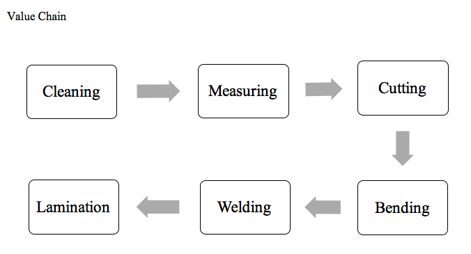

Processes

The metal that will be used should be cleaned first before processing through the CNC Machine. The pattern or the actual measurements of the metal will be inputted in the CNC Machine and this will result in releasing high pressure of water to clean the metal depending on its programmed pattern.

In making a pattern, they have this nail-like thing that is being pounded in a wood depending on the desired shape needed. This will help them know the measurement of the metal to be used. After the series of getting the needed measurement, it goes through the bending process. The worker will tramp his foot and the metal will be bended to form the metal according to the pattern. Next is the welding process, wherein the metals are joined together in order to create the sculpture of the metal. After finishing touches, the final output is ready to be shipped to the client. There is also this lamination section, wherein they create the base of the bag so that it will stand and be sturdy.

Equipment

Not all workers can work fast and accurate like a machine does. GuangQuiang Manufacturing Corporation invested on these machines to ensure the quality of their product to their suppliers.

CNC Machine Die Board Laser Cutting Machine Lamination Machine

Human Resource Requirements

They allot a quota for each worker to the make sure that they are productive enough to produce and meet the needed requirement of their client.

# **MEDTECS International Corporation**

Introduction

MEDTECS International Corporation limited is a company selling medical supplies. They focuses on supplying products like hospital scrubs, sheets and every cloth that is relating to an object in a hospital. They are the one who leads in distributing and manufacturing of hospital linens and clothing. They also offer various products other than linens and cloth, They also offer sterilized procedure tray products, anti-static surgical attire, under pads, boot covers, surgical gowns, medical bandages, surgical mask, surgical drapes and flame-retardant fabrics. Basically they provide anything the hospital needs. They have multiple factories based in different countries such Philippines, China and Cambodia. They also supply products in both Philippines and Taiwan, serving a total of 49 in both countries. They even had multiple partners in the Philippines and these are the following: Sacred Heart Medical Center, United Hospital Builders Inc.-Paranaque Doctor’s Hospital, Lucena United Doctors Hospital and Medical Center and etc.

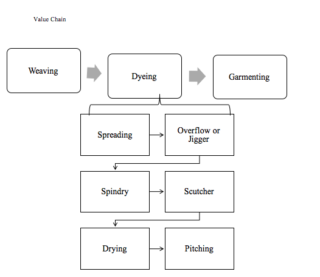

The manufacturing process of Medtecs is the simple way of producing linen and cloth which weaving, process and garmenting.

Processes

Medtecs design and creation process is a 4 step process line. The first being professional designing, here the design for the final product is to be visualized and produced virtually through a computer. After the design has been conceptualized it is then moved into the production line for mass production. The production line is divided into 3 sub processes namely Weaving, Dyeing and sewing.

The Medtecs manufacturing process is no different than other manufacturing companies that produce linen and cloth. Weaving, Dyeing and Sewing. First talking about weaving, Weaving started with warping. In warping the thread is separated into different sized. Then it undergoes whipping wherein, it is manually segreregated through in other for it to be easier for the machine to make fabric. It then goes to the weaving station wherein it is now being made into a fabric depending on what it it is supposed to be made. If its supposed to be satin or any other fabric said by the order.

It is then moved to dyeing, another facility in another building.

In dyeing it is first moved to the inspection center and there it is determined if there are any defects in the cloth produced from weaving. If there are any defects they are moved back to weaving to be reproduced. After being inspected it is moved to the scratcher. The scratcher stretches out the fabric for it to be ironed in the next step. In the scratching stage it is made to be in what size it is supposed to be.

Equipment:

- They multiple machiniries for each step of processes and each machine is a major component on their production.

Human Resource Requirements:

- Supervisors to help maintain the orderliness in the facility
- Manager to control the overall production and equipments
- Manpower to help the process to be done

# **FCF Manufacturing Corporation**

Introduction:

FCF Manufacturing Corporation is a manufacturing company also located in Bataan that speciliaze in making Coach bags, Coach accessories and anything that is related to Coach products. They are the one who exports Coach products in Jackson Ville (China), Korea, United States, Japan and many more. In a day the FCF Manufacturing Corporation makes around 200-300 bagss per day. They have around a thousand manpower and 48 production lines. The designs that we saw in the company will be released 3 months in the market, so they were very tight on us because they are afraid that they might be a leakage in their products. In keeping and maintaining their raw materials they store it in place that is 65 degrees below to maintain the quality of their raw materials. They have a high standard in the products that they produce, if there were defects and even a slight error in their products that they produce they will immediately dispose the that product.

Value Chain :

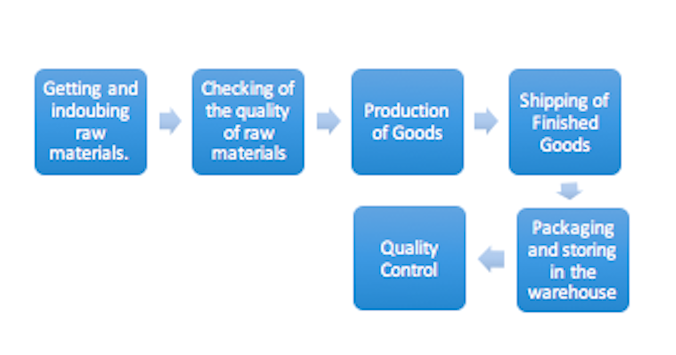

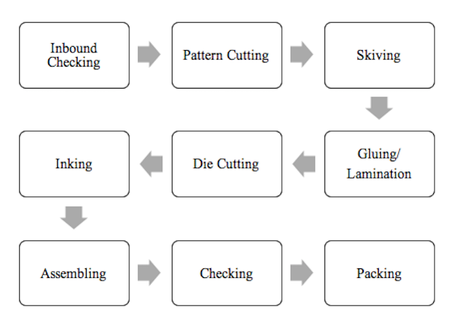

The first step in the process of making a Coach bag is inbound checking. In this process they will inspect the materials that will be using by Coach and its check by Coach if it will pass the standard. The second process is pattern cutting. In this process they will cut the leather or any materials that will be use specifically in their production lines. The third process in the production is Skiving. Skiving is a process wherein the edges of the leather are being reduced to make it easier to work with. And the fourth process is Gluing or Lamination. In this process they will combine the parts of a certain product like bags, wallets etc. to make more stabilize and stronger. The fifth process is die cutting. It is being done with the use of a machine to easily cut the materials in preparation for Laminated leather. The sixth process in production in Coach is inking. Painting the edges of the laminated leather to make it more authentic and stronger is being done in this process. Next process is the assembling or combining of all the pieces and other unfinished materials together. Followed by checking. In this process they will check the bags if it will pass the standards set by Coach and requirements needed in order to produce a final product. And lastly the final process is packing. In this process they will insert papers and other coverings for the bags and other products that the Coach produces to maintain the shape and stability of the products. And the final product will now be placed in a separate plastic and box in preparation of shipping or delivery.

Equipment

They use state of the art machines that specifically design and Coach patterns. They also have a state of the art facilities that they use to store their raw materials and to keep the products fresh and new.

Human Resource Requirements

The Human Resource Department of the FCF Manufacturing Corp. They set a high standard in recruiting multiple people for a certain and specific job at their company. They set multiple screening and interviews to assure that the person is qualified for a job in their company.

For the core of the tennis ball:

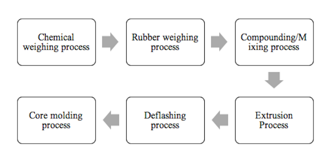

The first process in the creating of the core of the tennis ball is the chemical weighing process, in this process the calculation of the amount of chemicals are done to produce a tennis ball. And the second process in creating the core of a tennis ball is Rubber weighing process, in this process the addition of the right amount of rubber are being add in the mixer to produce a tennis ball. The next process is compound or mixing process. In this process the mixing of all the essential chemicals are put in together. Next is the extrusion, in this process a materials are being pushed through a machine to die of the desired cross-section. And followed by the next process which is Deflashing. In this process they are removing the excess molding of a tennis ball. And lastly the core molding process wherein the core of the tennis bal are being made and the surface of the core is being branded to place the adhesive later before placing it in the mold.

For Cloth Preparation:

For the process of preparing the cloth in the company the first process they did was the spreading process, in this process they spread out the fabric or cloth and then followed by the cloth clicking process and lastly the cloth dipping process wherein they dipped the cloths or fabric for it to dye.

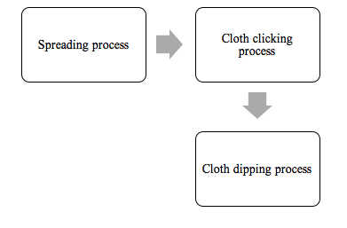

Once the core and cloth is ready:

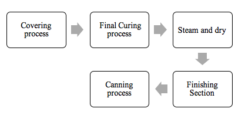

In this process once the cloth is ready the first process they will do is covering process. In this process they will cover the fabric or cloth to prepare it for next process which is Final Curing process. In final curing process they will finalize if the cloth has and defects. And the next process they will do is the steam and dry, they will steam and afterwards dry the cloth to prepare it for the next process. In finishing section they will check and prepare to cloths to be packed. In canning process which is the final process in the will packed and prepare the cloths and fabric and prepare it to be delivered.

Equipment:

The machineries for weighing the chemicals needed to form the tennis ball. It measures the chemical needed to form the tennis ball. Another processing machine is for the extension process. This machine is mainly use for the molding of the tennis ball. It perfectly shapes the mold to be round. Another machine is for deflashing process. It removes any excess or materials and they dispose. Another is for the molding process. It molds the core of the tennis ball and it makes the tennis ball round. And finally the machine use for packing the tennis balls. This machine solves the problem of the workers who are putting the balls one by one in the package. This machine can put many balls into several containers at once and also place a pressurized air to maintain the freshness and quality of the tennis balls. For the maintenance of their machineries they check them every end of the week to see if there are damage machines or malfunctioning ones but also they checked them daily to assure the proper functioning of there machines and of course to avoid a hindrance in their production.

Human resource:

As we all know Dunlop is one of the huge international company and it is one of the famous sport brand specifically in tennis in the market so in terms of hiring new employee’s they must place the work qualifications and expectation at a high level. Their Human Resource Department picks who is the most qualified among the applicants and they set various screen exam and test to assure that he is capable in working in their company.

Sources:

N.A( N.A) *Medtecs webpage.* Retrieved Nov 26.2017. from http://www.medtecs.com/

Porter.M(N,A) Porter’s Value Chain. Retrieved Nov 26.2017. from https://www.mindtools.com/pages/article/newSTR_66.htm.

N.A(N.A) *FAB website.* Retrieved on Nov 26.2017. from  
http://www.afablabor.com/job-opportunities/category/guangqiang-manufacturing-corporation